# Simulation Study: Bias Correction with Missing Outcomes

Comprehensive Evaluation of Oracle vs Feasible Correction

# Introduction

This simulation study evaluates the proposed bias decomposition and correction method using a Germany-calibrated factor model.

## Purpose

The simulation addresses two key questions:

**Part A: Bias Decomposition Validation**

> Does the decomposition $\hat{\gamma} \times \hat{\delta}$ accurately capture the actual deletion bias?

Using the **infeasible (oracle)** estimates where we observe full data for the omitted unit, we verify that the decomposition correctly identifies the systematic bias component.

**Part B: Feasible Correction Performance**

> How well does correction using only **partially observed** data perform compared to the oracle?

We compare the **feasible** correction (using only observed portions of the omitted donor’s outcomes) to the **infeasible/oracle** benchmark to assess practical performance.

## Estimators Compared

| Estimator | Description |
| --- | --- |
| **Complete Observations** | Vertical regression using all available data (gold standard) |
| **Complete gsynth** | Interactive fixed effects model (Xu 2017) using all available data |
| **Unit-wise Deletion** | Excluding the unit with missing outcomes |
| **Mean Imputation** | Imputing missing values with sample mean |
| **Median Imputation** | Imputing missing values with sample median |
| **Bias-corrected (Infeasible)** | Oracle benchmark using full data for omitted unit |
| **Bias-corrected (Feasible)** | Proposed method using only partially observed data |

The key distinction:

- **Infeasible/Oracle**: Uses information unavailable under genuine missingness, but shows what is recoverable in principle
- **Feasible**: Uses only the observed portion of the omitted donor’s outcomes

```r
library(scmsens)
library(dplyr)
library(tidyr)
library(tibble)
library(ggplot2)
library(stringr)
library(purrr)
library(ggrepel)
library(gsynth)
library(splines)
library(furrr)
library(knitr)
library(metR)

theme_set(theme_bw(base_size = 14) + theme(plot.title = element_text(hjust = 0.5)))

# Consistent color palette for all estimators
estimator_colors <- c(
    "Complete Observations" = "#4DAF4A",      # Green
    "Complete gsynth" = "#A65628",             # Brown
    "Unit-wise Deletion" = "#984EA3",          # Purple
    "Mean Imputation" = "#FF7F00",             # Orange
    "Median Imputation" = "#E6AB02",           # Gold
    "Bias-corrected (Infeasible)" = "#377EB8", # Blue
    "Bias-corrected (Feasible)" = "#E41A1C"    # Red
)
```

# Data-Generating Process

## Overview

The DGP is calibrated to the **West German reunification** example:

1. Fit a **two-factor interactive fixed effects (IFE)** model to the Germany data
2. **Augment** the estimated factors using spline models with stochastic noise
3. Select factor loadings from a subset of countries (Austria, USA, Japan, UK)
4. Generate synthetic data with **99 pre-treatment periods** and **1 post-treatment period**
5. Set the **true treatment effect to zero**

## Missingness Design

- **50% of pre-treatment periods** are set to missing for the omitted donor(s)
- Missingness pattern: `c(1:25, 51:75)` (two blocks)
- This represents a challenging but realistic scenario

```r
#' Run IFE simulation for a single dataset
run_ife_simulation <- function(synth_ife, miss_index = 1:50, k = 2, include_gsynth = FALSE) {
    if (!isTRUE(class(synth_ife) == "synth_ife")) {
        stop("synth_ife should be a synth_ife object")
    }

    tau_true <- synth_ife$tau
    df_pre <- synth_ife$df_pre_full
    t0 <- nrow(df_pre)
    n_control <- ncol(df_pre) - 1
    df_post <- synth_ife$df_prepost_full[(t0 + 1), ]
    donor_units <- paste0("X", 1:n_control)

    # Fit vertical regression with entire data (benchmark)
    tau_complete <- vertreg(
        formula = paste("Y ~", paste0("X", 1:n_control, collapse = "+")),
        data_pre = df_pre,
        data_post = df_post |> select(-D)
    )

    # Fit gsynth with entire data (optional comparator)
    if (isTRUE(include_gsynth)) {
        df_pre_long <- df_pre %>%
            mutate(time = 1:nrow(.)) |>
            pivot_longer(cols = -time, names_to = "unit", values_to = "outcome")
        df_prepost_long <- df_post |>
            select(-D) |>
            mutate(time = t0 + 1) |>
            pivot_longer(cols = -time, names_to = "unit", values_to = "outcome") |>
            mutate(treat = if_else(unit == "Y", 1, 0)) |>
            bind_rows(df_pre_long |> mutate(treat = 0))
        complete_gsynth_mod <- gsynth::gsynth(outcome ~ treat,
            data = df_prepost_long,
            index = c("unit", "time"),
            force = "none",
            CV = TRUE, r = c(0, 2),
            se = FALSE, inference = "parametric"
        )
        tau_gsynth <- complete_gsynth_mod$att.avg
    } else {
        tau_gsynth <- NA
    }

    # Generate all possible missing combinations
    combinations_result <- combn(donor_units, k, simplify = FALSE)

    # Compute vertical regression results for each combination
    res_vert <- map(combinations_result, get_vertreg_results,
        miss_index = miss_index,
        df_pre = df_pre,
        df_post = df_post,
        n_control = n_control,
        t0 = t0,
        tau_true = tau_true,
        tau_complete = tau_complete
    ) %>% bind_rows()

    # Combine with benchmark results
    sim_res <- data.frame(
        estimator = c("True Effect", "Complete Observations", "Complete gsynth"),
        tau = c(tau_true, tau_complete, tau_gsynth),
        tau_true = tau_true,
        tau_complete = tau_complete,
        gamma = c(NA, NA, NA),
        delta = c(NA, NA, NA),
        bias_est = c(NA, NA, NA),
        missing_var = NA,
        is_infeasible = NA,
        stringsAsFactors = FALSE
    ) |> bind_rows(res_vert)

    return(sim_res)
}

#' Compute vertical regression results with missing values
get_vertreg_results <- function(miss_var_name, miss_index, df_pre, df_post,
                                 n_control, t0, tau_true, tau_complete) {
    single_miss_flag <- isTRUE(length(miss_var_name) == 1)

    # Introduce missing values
    walk(miss_var_name, ~ {
        df_pre <<- df_pre %>%
            mutate("{.x}_miss" := if_else(row_number() %in% miss_index, NA_real_, !!sym(.x)))
    })
    walk(miss_var_name, ~ {
        df_post <<- df_post %>%
            mutate("{.x}_miss" := !!sym(.x))
    })

    obs_var_names <- paste0("X", 1:n_control) |> setdiff(miss_var_name)

    # Unit-wise Deletion
    tau_deletion <- vertreg(
        formula = paste("Y ~", paste0(obs_var_names, collapse = "+")),
        data_pre = df_pre,
        data_post = df_post |> select(-D)
    )

    # Bias Estimation
    if (single_miss_flag) {
        bias_est_infeasible <- estimate_params_partial(
            fm_z_on_x = paste(miss_var_name, "~ -1 +", paste0(obs_var_names, collapse = "+")),
            fm_y_on_z_and_x = paste0("Y ~ -1 +", paste0(c(obs_var_names, miss_var_name), collapse = "+")),
            data_pre = df_pre,
            data_post = df_post |> select(-D)
        )
        bias_est_feasible <- estimate_params_partial(
            fm_z_on_x = paste(paste0(miss_var_name, "_miss"), "~ -1 +", paste0(obs_var_names, collapse = "+")),
            fm_y_on_z_and_x = paste0("Y ~ -1 +", paste0(miss_var_name, "_miss"), "+", paste0(obs_var_names, collapse = "+")),
            data_pre = df_pre,
            data_post = df_post |> select(-D)
        )
        delta_infeasible <- bias_est_infeasible$delta
        delta_feasible <- bias_est_feasible$delta
    } else {
        bias_est_infeasible <- estimate_params_partial_multi(
            var_z_name = miss_var_name,
            var_x_name = obs_var_names,
            var_y_name = "Y",
            data_pre = df_pre,
            data_post = df_post |> select(-D)
        )
        bias_est_feasible <- estimate_params_partial_multi(
            var_z_name = paste0(miss_var_name, "_miss"),
            var_x_name = obs_var_names,
            var_y_name = "Y",
            data_pre = df_pre,
            data_post = df_post |> select(-D)
        )
        delta_infeasible <- bias_est_infeasible$imbalance
        delta_feasible <- bias_est_feasible$imbalance
    }

    # Imputation
    df_pre_long <- df_pre %>%
        mutate(time = 1:nrow(.)) |>
        pivot_longer(cols = -time, names_to = "unit", values_to = "outcome") |>
        filter(!unit %in% miss_var_name)
    df_prepost_long <- df_post |>
        select(-D) |>
        mutate(time = t0 + 1) |>
        pivot_longer(cols = -time, names_to = "unit", values_to = "outcome") |>
        filter(!unit %in% miss_var_name) |>
        mutate(treat = if_else(unit == "Y", 1, 0)) |>
        bind_rows(df_pre_long |> mutate(treat = 0))

    # Mean imputation
    df_prepost_long_mean <- df_prepost_long |>
        group_by(unit) |>
        mutate(outcome = if_else(is.na(outcome), mean(outcome, na.rm = TRUE), outcome)) |>
        ungroup()
    df_pre_mean <- df_prepost_long_mean |> filter(time <= t0) |> select(-treat) |>
        pivot_wider(names_from = "unit", values_from = "outcome") |> select(-time)
    df_post_mean <- df_prepost_long_mean |> filter(time > t0) |> select(-treat) |>
        pivot_wider(names_from = "unit", values_from = "outcome") |> select(-time)

    tau_mean_imp <- vertreg(
        formula = paste("Y ~", paste0(obs_var_names, collapse = "+"), "+",
                        paste0(paste0(miss_var_name, "_miss"), collapse = "+")),
        data_pre = df_pre_mean,
        data_post = df_post_mean |> as.data.frame()
    )

    # Median imputation
    df_prepost_long_median <- df_prepost_long |>
        group_by(unit) |>
        mutate(outcome = if_else(is.na(outcome), median(outcome, na.rm = TRUE), outcome)) |>
        ungroup()
    df_pre_median <- df_prepost_long_median |> filter(time <= t0) |> select(-treat) |>
        pivot_wider(names_from = "unit", values_from = "outcome") |> select(-time)
    df_post_median <- df_prepost_long_median |> filter(time > t0) |> select(-treat) |>
        pivot_wider(names_from = "unit", values_from = "outcome") |> select(-time)

    tau_median_imp <- vertreg(
        formula = paste("Y ~", paste0(obs_var_names, collapse = "+"), "+",
                        paste0(paste0(miss_var_name, "_miss"), collapse = "+")),
        data_pre = df_pre_median,
        data_post = df_post_median |> as.data.frame()
    )

    # Combine Results
    missing_var_label <- paste0(miss_var_name, collapse = ", ")

    res <- bind_rows(
        data.frame(estimator = "Unit-wise Deletion", tau = tau_deletion,
                   tau_true = tau_true, tau_complete = tau_complete,
                   gamma = NA_real_, delta = NA_real_, bias_est = NA_real_,
                   missing_var = missing_var_label, is_infeasible = NA),
        data.frame(estimator = "Mean Imputation", tau = tau_mean_imp,
                   tau_true = tau_true, tau_complete = tau_complete,
                   gamma = NA_real_, delta = NA_real_, bias_est = NA_real_,
                   missing_var = missing_var_label, is_infeasible = NA),
        data.frame(estimator = "Median Imputation", tau = tau_median_imp,
                   tau_true = tau_true, tau_complete = tau_complete,
                   gamma = NA_real_, delta = NA_real_, bias_est = NA_real_,
                   missing_var = missing_var_label, is_infeasible = NA),
        data.frame(estimator = "Bias-corrected (Infeasible)",
                   tau = tau_deletion - bias_est_infeasible$bias,
                   tau_true = tau_true, tau_complete = tau_complete,
                   gamma = bias_est_infeasible$gamma, delta = delta_infeasible,
                   bias_est = bias_est_infeasible$bias,
                   missing_var = missing_var_label, is_infeasible = TRUE),
        data.frame(estimator = "Bias-corrected (Feasible)",
                   tau = tau_deletion - bias_est_feasible$bias,
                   tau_true = tau_true, tau_complete = tau_complete,
                   gamma = bias_est_feasible$gamma, delta = delta_feasible,
                   bias_est = bias_est_feasible$bias,
                   missing_var = missing_var_label, is_infeasible = FALSE)
    )
    return(res)
}

#' Replace X labels with country names
replace_labels <- function(x, labels) {
    sapply(str_split(x, ",\\s*"), function(v) paste(labels[v], collapse = ", "))
}

#' Compute summary statistics
compute_summary_stats <- function(results, tau_true = 0) {
    results |>
        group_by(estimator) |>
        summarise(
            n = n(),
            mean_tau = mean(tau, na.rm = TRUE),
            mean_bias = mean(tau - tau_true, na.rm = TRUE),
            sd = sd(tau, na.rm = TRUE),
            rmse = sqrt(mean((tau - tau_true)^2, na.rm = TRUE)),
            mae = mean(abs(tau - tau_true), na.rm = TRUE),
            .groups = "drop"
        ) |>
        arrange(rmse)
}

#' Compute scenario-specific statistics
compute_scenario_stats <- function(results, tau_true = 0) {
    results |>
        filter(!is.na(missing_var)) |>
        group_by(missing_var, estimator) |>
        summarise(
            rmse = sqrt(mean((tau - tau_true)^2, na.rm = TRUE)),
            mean_bias = mean(tau - tau_true, na.rm = TRUE),
            .groups = "drop"
        )
}

#' Compute gap-recovered statistics
compute_gap_recovered <- function(results, tau_true = 0) {
    scenario_stats <- results |>
        filter(!is.na(missing_var)) |>
        group_by(missing_var, estimator) |>
        summarise(rmse = sqrt(mean((tau - tau_true)^2, na.rm = TRUE)), .groups = "drop") |>
        pivot_wider(names_from = estimator, values_from = rmse)

    scenario_stats |>
        mutate(
            deletion_gap = `Unit-wise Deletion` - `Bias-corrected (Infeasible)`,
            feasible_improvement = `Unit-wise Deletion` - `Bias-corrected (Feasible)`,
            gap_recovered_pct = if_else(
                deletion_gap > 0,
                feasible_improvement / deletion_gap * 100,
                NA_real_
            )
        ) |>
        select(missing_var,
               rmse_deletion = `Unit-wise Deletion`,
               rmse_infeasible = `Bias-corrected (Infeasible)`,
               rmse_feasible = `Bias-corrected (Feasible)`,
               gap_recovered_pct)
}
```

# Part 1: Fit IFE Model to West Germany Data

```r
data("wgermany")

wgermany_long <- wgermany |>
    pivot_longer(cols = !(year | Dt), names_to = "country", values_to = "gdp") |>
    mutate(treat = if_else(year >= 1990 & country == "West Germany", 1, 0))

set.seed(123)
gsynth_fit <- gsynth(gdp ~ treat,
    data = wgermany_long,
    index = c("country", "year"),
    force = "none",
    CV = TRUE, r = c(0, 2),
    se = TRUE, inference = "parametric", nboots = 1000,
    parallel = FALSE
)
```

```
#> Cross-validating ...
#>  r = 0; sigma2 = 80147317.87269; IC = 18.20869; PC = 80033472.25071; MSPE = 43094060.53263
#>  r = 1; sigma2 = 6158685.08031; IC = 16.19219; PC = 12243181.27108; MSPE = 973117.84765
#>  r = 2; sigma2 = 436739.98706; IC = 14.07679; PC = 1301558.93513; MSPE = 10122.80151
#>
#>  r* = 2
#>
#> Simulating errors .............Bootstrapping ...
#> ..........
```

```r
wgerm_factor <- gsynth_fit$factor
wgerm_loading <- rbind(gsynth_fit$lambda.co, gsynth_fit$lambda.tr) |>
    as.data.frame()
```

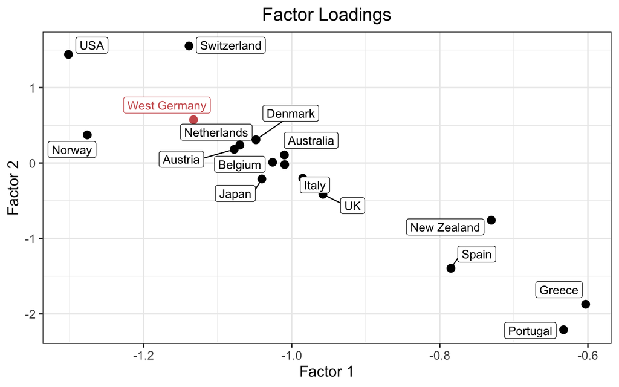

Factor loadings from the IFE model fitted to West Germany data

```r
wgerm_loading %>%
    mutate(unit = rownames(.)) |>
    mutate(treat = if_else(unit == "West Germany", "Treated", "Control")) |>
    ggplot(aes(x = r1, y = r2, color = treat)) +
    scale_color_manual(name = "Group", values = c("black", "indianred")) +
    geom_point(size = 3) +
    geom_label_repel(aes(label = unit), box.padding = 0.35, point.padding = 0.5) +
    labs(title = "Factor Loadings", x = "Factor 1", y = "Factor 2") +
    theme(legend.position = "none")
```

# Part 2: Augment Factors

```r
factor_df <- data.frame(
    time = 1:nrow(wgerm_factor),
    factor1 = wgerm_factor[, 1],
    factor2 = wgerm_factor[, 2]
)

mod_factor1 <- lm(factor1 ~ bs(time, df = 5), data = factor_df)
mod_factor2 <- lm(factor2 ~ bs(time, df = 6), data = factor_df)

pre_time <- -c(rev(seq(0, floor((99 - nrow(wgerm_factor)) * (3 / 4)))))
post_time <- seq(nrow(wgerm_factor) + 1, length = round((99 - nrow(wgerm_factor)) / 4))

set.seed(123)
aug_factor1 <- predict(mod_factor1, newdata = data.frame(time = c(pre_time, post_time))) +
    rnorm(length(c(pre_time, post_time)), 0, 100)
aug_factor2 <- predict(mod_factor2, newdata = data.frame(time = c(pre_time, post_time))) +
    rnorm(length(c(pre_time, post_time)), 0, 100)

aug_factor_df <- rbind(
    factor_df,
    data.frame(time = c(pre_time, post_time), factor1 = aug_factor1, factor2 = aug_factor2)
) |> arrange(time)
```

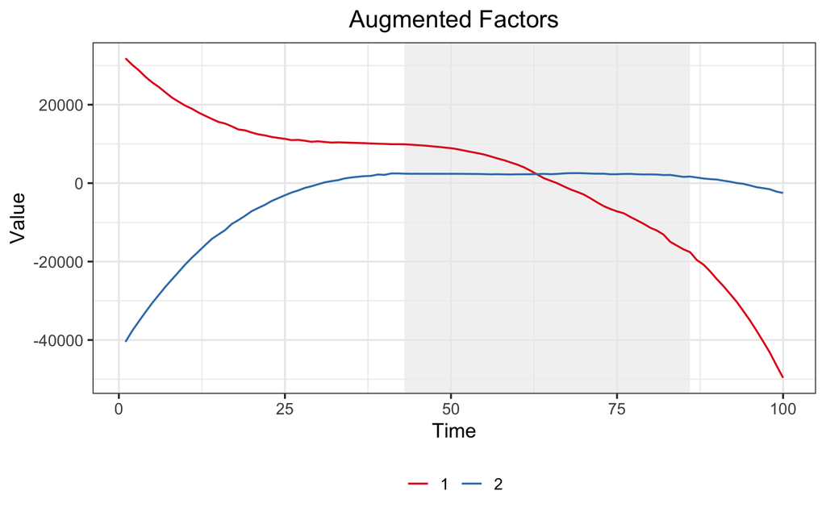

Augmented factors (gray region = original Germany data)

```r
aug_factor_df |>
    pivot_longer(-time, names_to = "factors", values_to = "value") |>
    mutate(factors = str_remove(factors, "factor")) |>
    mutate(time = time - min(time) + 1) |>
    ggplot(aes(x = time, y = value, color = factors)) +
    geom_rect(aes(xmin = length(pre_time) + 1, xmax = length(pre_time) + nrow(wgerm_factor),
                  ymin = -Inf, ymax = Inf),
              fill = "grey90", color = NA, alpha = 0.03) +
    geom_line() +
    labs(title = "Augmented Factors", x = "Time", y = "Value") +
    scale_color_brewer(NULL, type = "qual", palette = "Set1") +
    theme(legend.position = "bottom")
```

# Part 3: Monte Carlo Simulation

```r
# Subset to selected countries
selected_units <- c("Austria", "USA", "Japan", "UK", "West Germany")
names(selected_units) <- paste0("X", 1:length(selected_units))

loading_df <- wgerm_loading %>% filter(rownames(.) %in% selected_units)

n_control <- nrow(loading_df) - 1
t0 <- nrow(aug_factor_df) - 1
phi <- loading_df |> as.matrix()
mu <- rbind(aug_factor_df$factor1, aug_factor_df$factor2)

tau_true <- 0
miss_index <- c(1:25, 51:75)  # Two blocks, 50% missing
sim_size <- 1000
```

**Simulation Parameters:**

- Pre-treatment periods: 99
- Control units: 4 (Austria, USA, Japan, UK) — the three largest-weight donors from the original Abadie et al. study plus UK
- True treatment effect: 0
- Missingness: 50% (periods 1-25 and 51-75)
- Monte Carlo iterations: 1000

### What is Fixed vs Randomized

**Fixed across all iterations:**

| Component | Description | Source |
| --- | --- | --- |
| Factor loadings ($\phi$) | Unit-specific weights on latent factors | Estimated from West Germany data via `gsynth` |
| Time factors ($\mu$) | Two latent factors over 100 time periods | Original from Germany (t=43-87) + spline extrapolation with fixed seed |
| True treatment effect ($\tau$) | Set to 0 for bias evaluation | Design choice |
| Pre-treatment periods ($T_0$) | 99 periods | Design choice |
| Missingness pattern | Periods 1-25 and 51-75 (50% missing) | Design choice |
| Selected units | Austria, USA, Japan, UK + West Germany | Top-weighted donors from original study |

**Randomized in each iteration:**

| Component | Description | How |
| --- | --- | --- |
| Idiosyncratic noise ($\varepsilon_{it}$) | Unit-time specific shocks | `rnorm()` with seed = iteration number |
| Omitted unit scenario | Which control unit has missing data | All 4 units are tested in each iteration |

**Data Generating Process:**

Each simulated outcome is generated as:
$$Y_{it} = \phi_i' \mu_t +
\varepsilon_{it}$$

where:

- $\phi_i$ = factor loadings for unit $i$ (fixed, from Germany estimation)
- $\mu_t$ = time factors at period $t$ (fixed, augmented from Germany)
- $\varepsilon_{it} \sim N(0, \sigma^2)$ = idiosyncratic noise (randomized each iteration)

The treatment effect for the treated unit (West Germany) at $t = T_0 + 1$ is set to $\tau = 0$.

**Missingness Design:**

For each omitted unit, we observe outcomes only for periods **26-50** and **76-99** (the “partially observed” data). This creates a challenging scenario where:

- The feasible correction must estimate bias using only 50% of the omitted unit’s pre-treatment data
- The oracle/infeasible correction uses all 99 pre-treatment periods

```r
plan(multisession)

# Single-unit missing (k = 1)
res_drop1_raw <- future_map(1:sim_size, function(seed) {
    set.seed(seed)
    synth_ife_data <- generate_synth_data_ife(
        t0 = t0, n = n_control, tau = tau_true, phi = phi, mu = mu
    )
    res <- run_ife_simulation(synth_ife_data, miss_index = miss_index, k = 1, include_gsynth = TRUE)
    res |> mutate(
        id = seed,
        missing_var = if_else(is.na(missing_var), missing_var,
                              replace_labels(missing_var, selected_units))
    )
}, .options = furrr_options(seed = NULL), .progress = TRUE) |> bind_rows()
```

[output not shown]

[output cut: 6937 more lines]

[output not shown]

```r
# Multi-unit missing (k = 2)
res_drop2_raw <- future_map(1:sim_size, function(seed) {
    set.seed(seed)
    synth_ife_data <- generate_synth_data_ife(
        t0 = t0, n = n_control, tau = tau_true, phi = phi, mu = mu
    )
    res <- run_ife_simulation(synth_ife_data, miss_index = miss_index, k = 2, include_gsynth = TRUE)
    res |> mutate(
        id = seed,
        missing_var = if_else(is.na(missing_var), missing_var,
                              replace_labels(missing_var, selected_units))
    )
}, .options = furrr_options(seed = NULL), .progress = TRUE) |> bind_rows()
```

[output not shown]

[output cut: 6944 more lines]

[output not shown]

# Results: Single Missing Unit (k = 1)

We organize the results into two parts:

- **Part A**: Does the bias decomposition accurately capture deletion bias? (Theory validation)
- **Part B**: Does correction using partial data work? (Practical utility)

## Overall Performance

```r
tab_single_overall <- compute_summary_stats(res_drop1_raw, tau_true)

tab_single_overall |>
    filter(estimator != "True Effect") |>
    kable(digits = 3, caption = "Overall Performance: Single Missing Unit")
```

Overall Performance: Single Missing Unit

| estimator | n | mean_tau | mean_bias | sd | rmse | mae |
| --- | --- | --- | --- | --- | --- | --- |
| Complete Observations | 1000 | 0.006 | 0.006 | 1.241 | 1.240 | 1.010 |
| Bias-corrected (Infeasible) | 4000 | 0.006 | 0.006 | 1.241 | 1.240 | 1.010 |
| Bias-corrected (Feasible) | 4000 | 0.008 | 0.008 | 1.254 | 1.254 | 1.015 |
| Unit-wise Deletion | 4000 | 0.002 | 0.002 | 1.528 | 1.528 | 1.188 |
| Median Imputation | 4000 | -0.001 | -0.001 | 1.530 | 1.530 | 1.191 |
| Mean Imputation | 4000 | 0.000 | 0.000 | 1.530 | 1.530 | 1.191 |
| Complete gsynth | 1000 | 3.211 | 3.211 | 1.229 | 3.438 | 3.213 |

**Note on sample sizes (n):** Complete Observations and Complete gsynth have n=1000 (one per simulation) because they use all data regardless of which unit is “missing.” Other estimators have n=4000 because there are 4 possible omitted units × 1000 simulations.

**Note on gsynth performance:** gsynth is designed for settings with more units where factor estimation is reliable. In this simulation with only 5 units (4 controls + 1 treated), factor estimation is challenging and cross-validation for selecting the number of factors may be unstable. In applications with larger donor pools, results may change.

## Figure: Distribution of Estimates

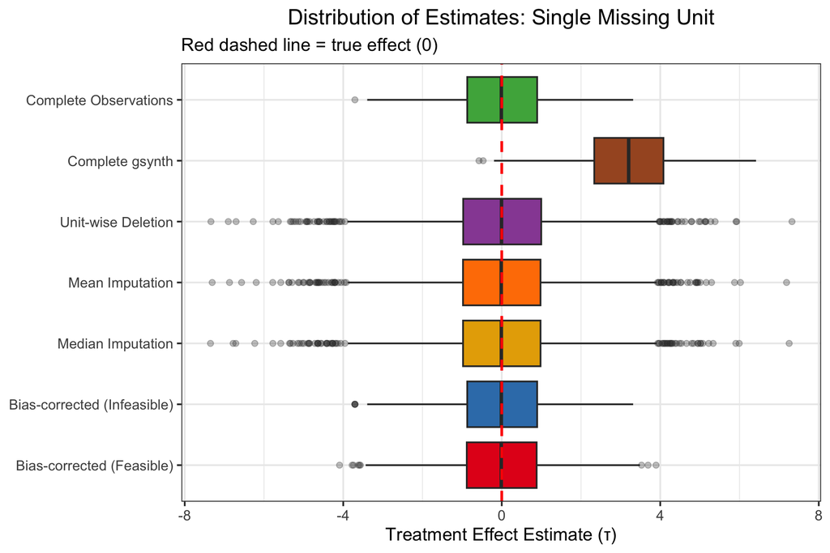

Box plots showing distribution of treatment effect estimates across 1000 simulations

```r
plot_order <- c("Complete Observations", "Complete gsynth", "Unit-wise Deletion",
                "Mean Imputation", "Median Imputation",
                "Bias-corrected (Infeasible)", "Bias-corrected (Feasible)")

res_drop1_raw |>
    filter(estimator %in% plot_order) |>
    mutate(estimator = factor(estimator, levels = rev(plot_order))) |>
    ggplot(aes(x = estimator, y = tau, fill = estimator)) +
    geom_boxplot(outlier.alpha = 0.3, show.legend = FALSE) +
    geom_hline(yintercept = 0, color = "red", linetype = "dashed", linewidth = 1) +
    coord_flip() +
    scale_fill_manual(values = estimator_colors) +
    labs(x = NULL, y = "Treatment Effect Estimate (τ)",
         title = "Distribution of Estimates: Single Missing Unit",
         subtitle = "Red dashed line = true effect (0)") +
    theme(axis.text.y = element_text(size = 11))
```

## Bias-Variance Decomposition by Scenario

Since RMSE² = Bias² + Variance, we can decompose the error for each omitted unit scenario:

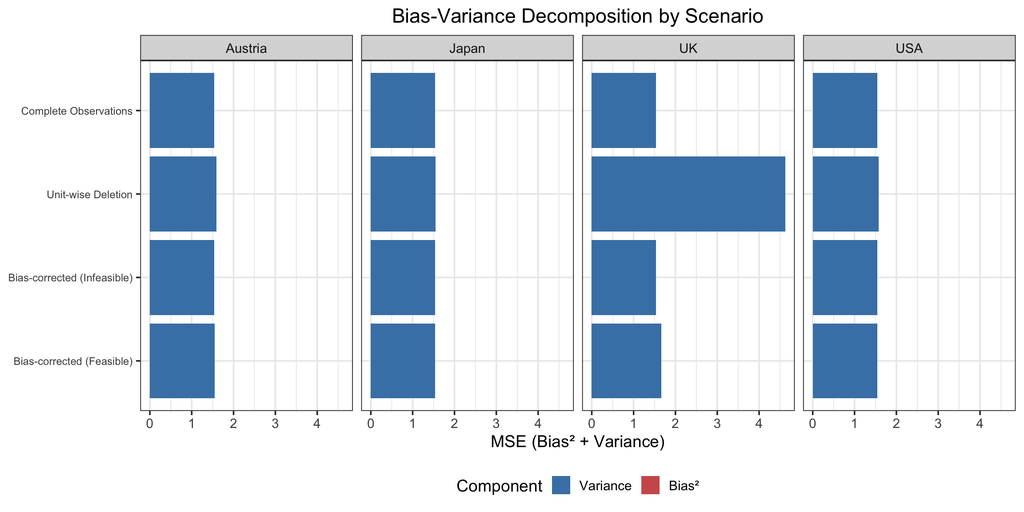

Bias-variance decomposition of MSE by omitted unit scenario.

```r
# Compute bias-variance by scenario
bv_by_scenario <- res_drop1_raw |>
    filter(estimator %in% c("Unit-wise Deletion", "Bias-corrected (Infeasible)", "Bias-corrected (Feasible)")) |>
    group_by(estimator, missing_var) |>
    summarise(
        mean_bias = mean(tau),
        bias_sq = mean(tau)^2,
        variance = var(tau),
        .groups = "drop"
    )

# Add Complete Observations (same for all scenarios)
complete_stats <- res_drop1_raw |>
    filter(estimator == "Complete Observations") |>
    summarise(
        mean_bias = mean(tau),
        bias_sq = mean(tau)^2,
        variance = var(tau)
    )

# Expand Complete Observations to all scenarios for comparison
complete_expanded <- expand.grid(
    estimator = "Complete Observations",
    missing_var = unique(bv_by_scenario$missing_var)
) |>
    mutate(
        mean_bias = complete_stats$mean_bias,
        bias_sq = complete_stats$bias_sq,
        variance = complete_stats$variance
    )

bv_all <- bind_rows(bv_by_scenario, complete_expanded) |>
    mutate(estimator = factor(estimator,
           levels = rev(c("Complete Observations", "Unit-wise Deletion",
                          "Bias-corrected (Infeasible)", "Bias-corrected (Feasible)"))))

bv_all |>
    select(estimator, missing_var, `Bias²` = bias_sq, Variance = variance) |>
    pivot_longer(c(`Bias²`, Variance), names_to = "Component", values_to = "value") |>
    mutate(Component = factor(Component, levels = c("Variance", "Bias²"))) |>
    ggplot(aes(x = estimator, y = value, fill = Component)) +
    geom_col() +
    coord_flip() +
    facet_wrap(~ missing_var, nrow = 1) +
    scale_fill_manual(values = c("Bias²" = "indianred", "Variance" = "steelblue")) +
    labs(x = NULL, y = "MSE (Bias² + Variance)",
         title = "Bias-Variance Decomposition by Scenario") +
    theme(legend.position = "bottom",
          axis.text.y = element_text(size = 9))
```

## Part A: Bias Decomposition Validation

**Question:** Does the decomposition $\hat{\gamma} \times \hat{\delta}$ accurately capture the actual deletion bias?

This uses the **infeasible (oracle)** estimates where we observe the full data for the omitted unit.

### Sensitivity Plot with Oracle Estimates

Using `plot_sensitivity()` from the scmsens package, we show the **mean** oracle estimates for each omitted unit. The contour lines show the adjusted treatment effect at each (γ, δ) combination.

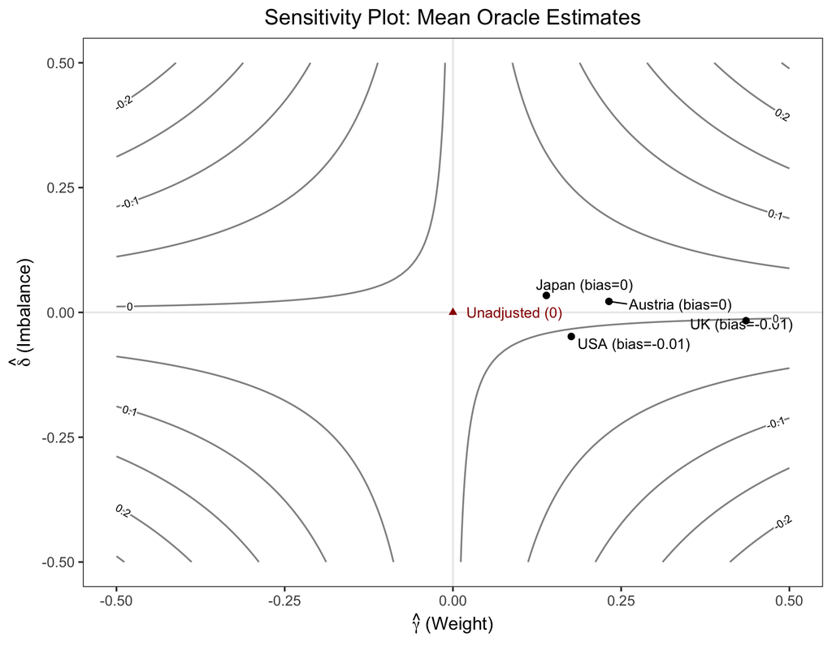

Sensitivity plot using scmsens::plot_sensitivity() with mean oracle estimates for each omitted unit.

```r
# Get oracle estimates
oracle_data <- res_drop1_raw |>
    filter(estimator == "Bias-corrected (Infeasible)") |>
    select(id, missing_var, gamma, delta, bias_est)

# Compute mean oracle estimates for each omitted unit
oracle_summary <- oracle_data |>
    group_by(missing_var) |>
    summarise(
        mean_gamma = mean(gamma),
        mean_delta = mean(delta),
        mean_bias = mean(bias_est),
        .groups = "drop"
    )

# Get tau_complete (should be consistent across simulations)
tau_complete_val <- res_drop1_raw |>
    filter(estimator == "Complete Observations") |>
    pull(tau) |>
    mean()

# Use plot_sensitivity from scmsens and add contour labels
p <- plot_sensitivity(
    tau_complete = tau_complete_val,
    var_x_gamma = oracle_summary$mean_gamma,
    var_x_delta = oracle_summary$mean_delta,
    var_x_name = paste0(oracle_summary$missing_var, " (bias=", round(oracle_summary$mean_bias, 2), ")"),
    title = "Sensitivity Plot: Mean Oracle Estimates",
    repel = TRUE,
    text_size = 4
)

# Add contour labels using metR
gamma_seq <- seq(round(min(oracle_summary$mean_gamma), 0) - 0.5,
                 round(max(oracle_summary$mean_gamma), 0) + 0.5, length.out = 100)
delta_seq <- seq(round(min(oracle_summary$mean_delta), 0) - 0.5,
                 round(max(oracle_summary$mean_delta), 0) + 0.5, length.out = 100)
sens_df <- expand.grid(gamma = gamma_seq, delta = delta_seq) |>
    mutate(tau_adj = tau_complete_val + gamma * delta)

p + metR::geom_text_contour(data = sens_df, aes(x = gamma, y = delta, z = tau_adj),
                            stroke = 0.2, size = 3, skip = 1)
```

### Sensitivity Plot with Simulation Scatter

To show the variability across simulations, we overlay all oracle points on the sensitivity contours:

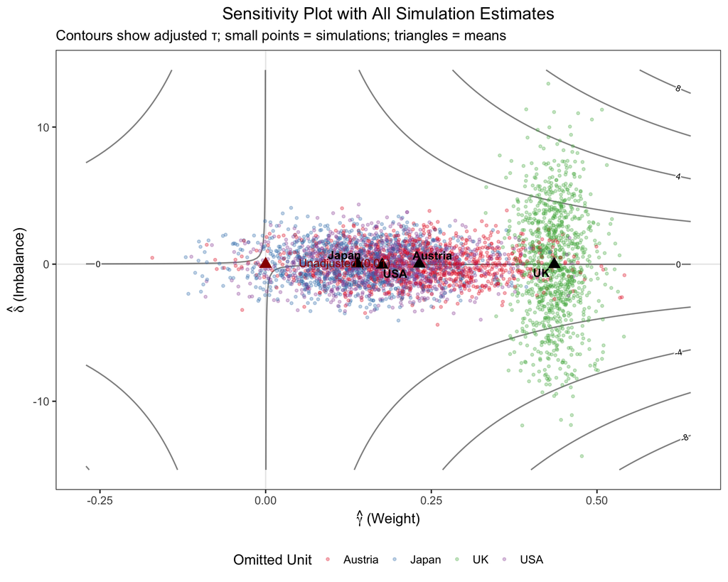

Sensitivity contour plot with all simulation oracle estimates overlaid.

```r
# Create grid for contours
gamma_range <- range(oracle_data$gamma, na.rm = TRUE)
delta_range <- range(oracle_data$delta, na.rm = TRUE)

gamma_seq <- seq(gamma_range[1] - 0.1, gamma_range[2] + 0.1, length.out = 100)
delta_seq <- seq(delta_range[1] - 1, delta_range[2] + 1, length.out = 100)

contour_grid <- expand.grid(gamma = gamma_seq, delta = delta_seq) |>
    mutate(tau_adj = tau_complete_val + gamma * delta)

# Plot with package-style contours (showing adjusted tau, not just bias)
ggplot() +
    geom_vline(xintercept = 0, color = "black", alpha = 0.1) +
    geom_hline(yintercept = 0, color = "black", alpha = 0.1) +
    # Contour lines (adjusted treatment effect)
    geom_contour(data = contour_grid, aes(x = gamma, y = delta, z = tau_adj),
                 color = "black", alpha = 0.5) +
    metR::geom_text_contour(data = contour_grid, aes(x = gamma, y = delta, z = tau_adj),
                            stroke = 0.2, size = 3, skip = 1) +
    # Simulation points (background)
    geom_point(data = oracle_data, aes(x = gamma, y = delta, color = missing_var),
               alpha = 0.3, size = 1) +
    # Mean oracle points (foreground)
    geom_point(data = oracle_summary, aes(x = mean_gamma, y = mean_delta),
               size = 4, shape = 17, color = "black") +
    ggrepel::geom_text_repel(
        data = oracle_summary,
        aes(x = mean_gamma, y = mean_delta, label = missing_var),
        size = 4, fontface = "bold"
    ) +
    # Unadjusted estimate at origin
    geom_point(aes(x = 0, y = 0), shape = 17, color = "#990000", size = 4) +
    annotate("text", x = 0.05, y = 0.1,
             label = paste0("Unadjusted (", round(tau_complete_val, 2), ")"),
             color = "#990000", hjust = 0, size = 4) +
    scale_color_brewer(palette = "Set1") +
    labs(x = expression(hat(gamma) ~ "(Weight)"),
         y = expression(hat(delta) ~ "(Imbalance)"),
         color = "Omitted Unit",
         title = "Sensitivity Plot with All Simulation Estimates",
         subtitle = "Contours show adjusted τ; small points = simulations; triangles = means") +
    theme(legend.position = "bottom",
          panel.grid.major = element_blank(),
          panel.grid.minor = element_blank())
```

**Interpretation:** - Contour lines show the **adjusted treatment effect** at each (γ, δ) combination - Small points show oracle estimates from each simulation (clustering = consistency) - Triangles show mean estimates for each omitted unit - The red triangle at origin shows the unadjusted (complete observations) estimate

### Decomposition Accuracy

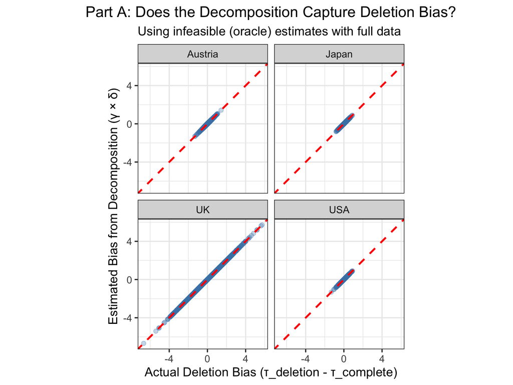

Scatter plot showing actual deletion bias vs estimated bias from the decomposition. Points on the 45-degree line indicate perfect decomposition accuracy.

```r
deletion_data <- res_drop1_raw |>
    filter(estimator == "Unit-wise Deletion") |>
    select(id, missing_var, tau_deletion = tau, tau_complete)

infeasible_data <- res_drop1_raw |>
    filter(estimator == "Bias-corrected (Infeasible)") |>
    select(id, missing_var, bias_est_infeasible = bias_est)

plot_data_A <- deletion_data |>
    left_join(infeasible_data, by = c("id", "missing_var")) |>
    mutate(actual_deletion_bias = tau_deletion - tau_complete)

ggplot(plot_data_A, aes(x = actual_deletion_bias, y = bias_est_infeasible)) +
    geom_point(alpha = 0.3, color = "steelblue") +
    geom_abline(slope = 1, intercept = 0, color = "red", linetype = "dashed", linewidth = 1) +
    labs(x = "Actual Deletion Bias (τ_deletion - τ_complete)",
         y = "Estimated Bias from Decomposition (γ × δ)",
         title = "Part A: Does the Decomposition Capture Deletion Bias?",
         subtitle = "Using infeasible (oracle) estimates with full data") +
    coord_fixed() +
    facet_wrap(~ missing_var, ncol = 2)
```

### Decomposition Accuracy Statistics

```r
decomp_accuracy <- plot_data_A |>
    group_by(missing_var) |>
    summarise(
        correlation = cor(actual_deletion_bias, bias_est_infeasible),
        mean_actual_bias = mean(actual_deletion_bias),
        mean_estimated_bias = mean(bias_est_infeasible),
        rmse_decomposition = sqrt(mean((actual_deletion_bias - bias_est_infeasible)^2)),
        .groups = "drop"
    )

decomp_accuracy |>
    kable(digits = 3, caption = "Decomposition Accuracy: How well does γ×δ capture actual deletion bias?")
```

Decomposition Accuracy: How well does γ×δ capture actual deletion bias?

| missing_var | correlation | mean_actual_bias | mean_estimated_bias | rmse_decomposition |
| --- | --- | --- | --- | --- |
| Austria | 1 | 0.002 | 0.002 | 0 |
| Japan | 1 | 0.004 | 0.004 | 0 |
| UK | 1 | -0.010 | -0.010 | 0 |
| USA | 1 | -0.010 | -0.010 | 0 |

**Interpretation:** Correlation close to 1 and low RMSE indicate the decomposition accurately captures the systematic deletion bias.

## Part B: Feasible Correction Performance

**Question:** How well does correction using only **partially observed** data perform compared to the oracle?

This compares the **feasible** correction (using partial data) to the **infeasible** correction (using full data).

### Scenario-Specific Performance

```r
tab_single_scenario <- compute_scenario_stats(res_drop1_raw, tau_true)

tab_single_scenario |>
    filter(estimator %in% c("Unit-wise Deletion", "Bias-corrected (Infeasible)", "Bias-corrected (Feasible)")) |>
    select(-mean_bias) |>
    pivot_wider(names_from = estimator, values_from = rmse) |>
    kable(digits = 3, caption = "RMSE by Omitted Unit")
```

RMSE by Omitted Unit

| missing_var | Bias-corrected (Feasible) | Bias-corrected (Infeasible) | Unit-wise Deletion |
| --- | --- | --- | --- |
| Austria | 1.243 | 1.24 | 1.263 |
| Japan | 1.240 | 1.24 | 1.242 |
| UK | 1.290 | 1.24 | 2.149 |
| USA | 1.243 | 1.24 | 1.257 |

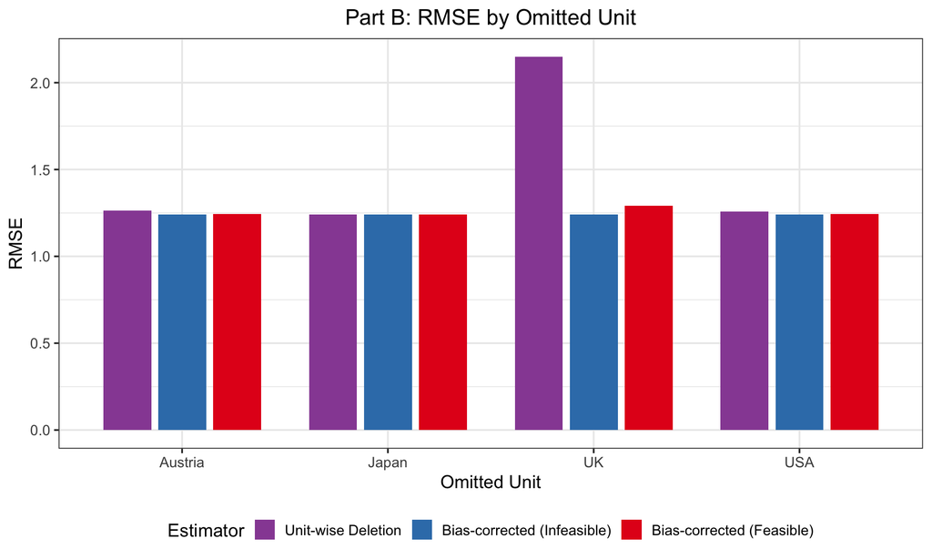

RMSE by omitted unit showing deletion, oracle, and feasible correction

```r
tab_single_scenario |>
    filter(estimator %in% c("Unit-wise Deletion", "Bias-corrected (Infeasible)", "Bias-corrected (Feasible)")) |>
    mutate(estimator = factor(estimator, levels = c("Unit-wise Deletion", "Bias-corrected (Infeasible)", "Bias-corrected (Feasible)"))) |>
    ggplot(aes(x = missing_var, y = rmse, fill = estimator)) +
    geom_col(position = position_dodge(width = 0.8), width = 0.7) +
    scale_fill_manual(values = estimator_colors) +
    labs(x = "Omitted Unit", y = "RMSE", fill = "Estimator",
         title = "Part B: RMSE by Omitted Unit") +
    theme(legend.position = "bottom")
```

### Gap Recovered

**Gap Recovered** measures what fraction of the deletion bias the feasible correction removes, relative to the oracle:

$$\text{Gap Recovered} =
\frac{\text{RMSE}_{\text{deletion}} -
\text{RMSE}_{\text{feasible}}}{\text{RMSE}_{\text{deletion}} -
\text{RMSE}_{\text{infeasible}}} \times 100\%$$

- **100%** means feasible correction fully matches the oracle
- **0%** means feasible correction provides no improvement over deletion

```r
tab_gap_recovered <- compute_gap_recovered(res_drop1_raw, tau_true)
tab_gap_recovered |>
    kable(digits = 3, caption = "Gap Recovered by Feasible Correction")
```

Gap Recovered by Feasible Correction

| missing_var | rmse_deletion | rmse_infeasible | rmse_feasible | gap_recovered_pct |
| --- | --- | --- | --- | --- |
| Austria | 1.263 | 1.24 | 1.243 | 90.475 |
| Japan | 1.242 | 1.24 | 1.240 | 104.606 |
| UK | 2.149 | 1.24 | 1.290 | 94.526 |
| USA | 1.257 | 1.24 | 1.243 | 85.972 |

### Feasible vs Oracle Correction

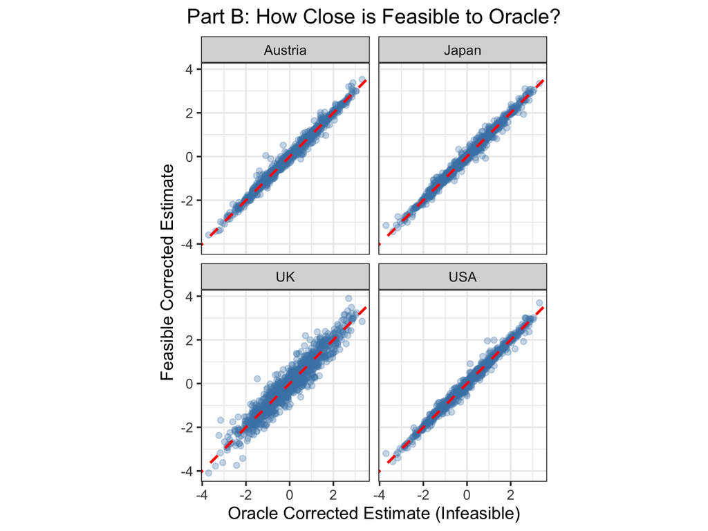

Scatter plot comparing feasible correction to oracle correction. Points on the 45-degree line indicate feasible matches oracle.

```r
res_drop1_raw |>
    filter(estimator %in% c("Bias-corrected (Infeasible)", "Bias-corrected (Feasible)")) |>
    select(id, missing_var, estimator, tau) |>
    pivot_wider(names_from = estimator, values_from = tau) |>
    ggplot(aes(x = `Bias-corrected (Infeasible)`, y = `Bias-corrected (Feasible)`)) +
    geom_point(alpha = 0.3, color = "steelblue") +
    geom_abline(slope = 1, intercept = 0, color = "red", linetype = "dashed", linewidth = 1) +
    labs(x = "Oracle Corrected Estimate (Infeasible)",
         y = "Feasible Corrected Estimate",
         title = "Part B: How Close is Feasible to Oracle?") +
    coord_fixed() +
    facet_wrap(~ missing_var, ncol = 2)
```

### Feasible vs Oracle Correlation

```r
feasible_oracle_corr <- res_drop1_raw |>
    filter(estimator %in% c("Bias-corrected (Infeasible)", "Bias-corrected (Feasible)")) |>
    select(id, missing_var, estimator, tau) |>
    pivot_wider(names_from = estimator, values_from = tau) |>
    group_by(missing_var) |>
    summarise(
        correlation = cor(`Bias-corrected (Infeasible)`, `Bias-corrected (Feasible)`),
        mean_gap = mean(`Bias-corrected (Feasible)` - `Bias-corrected (Infeasible)`),
        rmse_gap = sqrt(mean((`Bias-corrected (Feasible)` - `Bias-corrected (Infeasible)`)^2)),
        .groups = "drop"
    )

feasible_oracle_corr |>
    kable(digits = 3, caption = "Feasible vs Oracle: How similar are the corrections?")
```

Feasible vs Oracle: How similar are the corrections?

| missing_var | correlation | mean_gap | rmse_gap |
| --- | --- | --- | --- |
| Austria | 0.992 | 0.008 | 0.153 |
| Japan | 0.994 | 0.005 | 0.141 |
| UK | 0.954 | -0.009 | 0.386 |
| USA | 0.993 | 0.003 | 0.143 |

# Results: Two Missing Units (k = 2)

## Overall Performance

```r
tab_multi_overall <- compute_summary_stats(res_drop2_raw, tau_true)

tab_multi_overall |>
    filter(estimator != "True Effect") |>
    kable(digits = 3, caption = "Overall Performance: Two Missing Units")
```

Overall Performance: Two Missing Units

| estimator | n | mean_tau | mean_bias | sd | rmse | mae |
| --- | --- | --- | --- | --- | --- | --- |
| Bias-corrected (Infeasible) | 6000 | 0.006 | 0.006 | 1.241 | 1.240 | 1.010 |
| Complete Observations | 1000 | 0.006 | 0.006 | 1.241 | 1.240 | 1.010 |
| Bias-corrected (Feasible) | 6000 | 0.020 | 0.020 | 1.323 | 1.323 | 1.066 |
| Unit-wise Deletion | 6000 | 0.023 | 0.023 | 3.000 | 3.000 | 1.989 |
| Median Imputation | 6000 | 0.018 | 0.018 | 3.025 | 3.025 | 1.999 |
| Mean Imputation | 6000 | 0.025 | 0.025 | 3.058 | 3.058 | 2.016 |
| Complete gsynth | 1000 | 3.211 | 3.211 | 1.229 | 3.438 | 3.213 |

**Note on sample sizes (n):** Complete Observations and Complete gsynth have n=1000 (one per simulation) because they use all data regardless of which units are “missing.” Other estimators have n=6000 because there are 6 missing-unit combinations (C(4,2)=6) × 1000 simulations.

## Figure: Distribution of Estimates

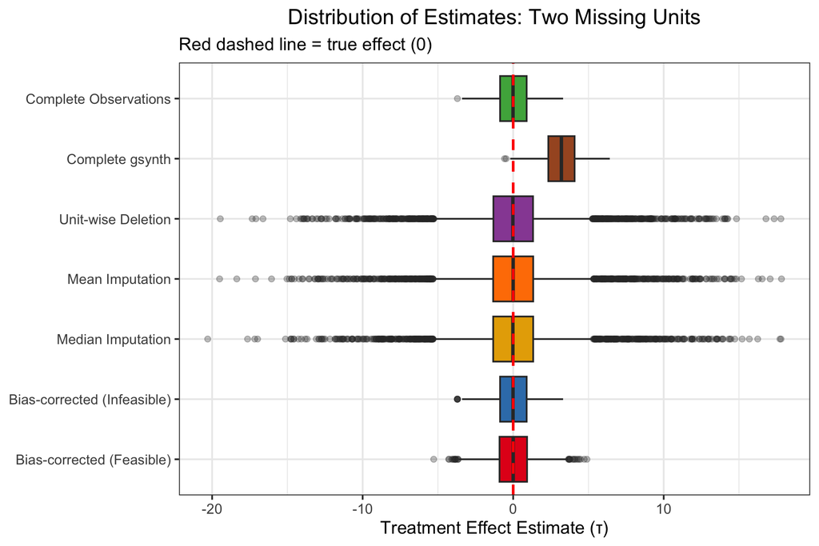

Box plots showing distribution of treatment effect estimates across 1000 simulations (two missing units)

```r
res_drop2_raw |>
    filter(estimator %in% plot_order) |>
    mutate(estimator = factor(estimator, levels = rev(plot_order))) |>
    ggplot(aes(x = estimator, y = tau, fill = estimator)) +
    geom_boxplot(outlier.alpha = 0.3, show.legend = FALSE) +
    geom_hline(yintercept = 0, color = "red", linetype = "dashed", linewidth = 1) +
    coord_flip() +
    scale_fill_manual(values = estimator_colors) +
    labs(x = NULL, y = "Treatment Effect Estimate (τ)",
         title = "Distribution of Estimates: Two Missing Units",
         subtitle = "Red dashed line = true effect (0)") +
    theme(axis.text.y = element_text(size = 11))
```

## Bias-Variance Decomposition by Scenario

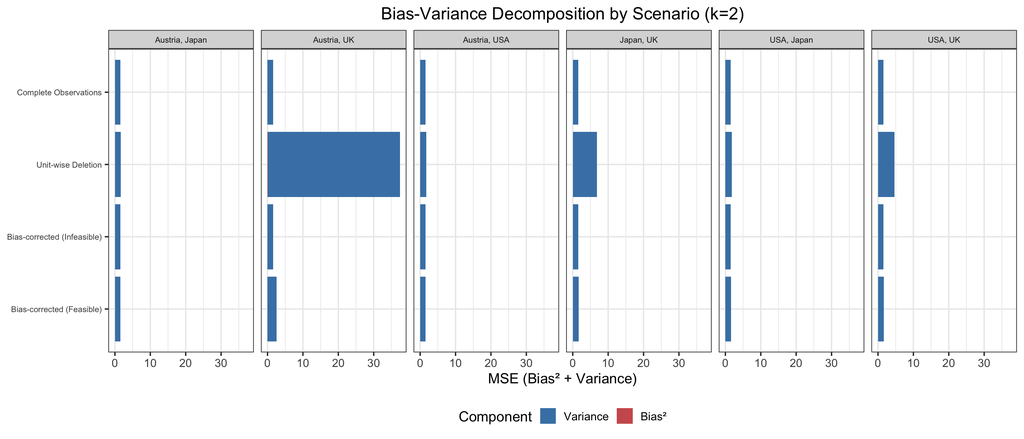

Bias-variance decomposition of MSE by omitted unit pair scenario (k=2).

```r
# Compute bias-variance by scenario
bv_by_scenario_k2 <- res_drop2_raw |>
    filter(estimator %in% c("Unit-wise Deletion", "Bias-corrected (Infeasible)", "Bias-corrected (Feasible)")) |>
    group_by(estimator, missing_var) |>
    summarise(
        mean_bias = mean(tau),
        bias_sq = mean(tau)^2,
        variance = var(tau),
        .groups = "drop"
    )

# Expand Complete Observations to all scenarios for comparison
complete_expanded_k2 <- expand.grid(
    estimator = "Complete Observations",
    missing_var = unique(bv_by_scenario_k2$missing_var)
) |>
    mutate(
        mean_bias = complete_stats$mean_bias,
        bias_sq = complete_stats$bias_sq,
        variance = complete_stats$variance
    )

bv_all_k2 <- bind_rows(bv_by_scenario_k2, complete_expanded_k2) |>
    mutate(estimator = factor(estimator,
           levels = rev(c("Complete Observations", "Unit-wise Deletion",
                          "Bias-corrected (Infeasible)", "Bias-corrected (Feasible)"))))

bv_all_k2 |>
    select(estimator, missing_var, `Bias²` = bias_sq, Variance = variance) |>
    pivot_longer(c(`Bias²`, Variance), names_to = "Component", values_to = "value") |>
    mutate(Component = factor(Component, levels = c("Variance", "Bias²"))) |>
    ggplot(aes(x = estimator, y = value, fill = Component)) +
    geom_col() +
    coord_flip() +
    facet_wrap(~ missing_var, nrow = 1) +
    scale_fill_manual(values = c("Bias²" = "indianred", "Variance" = "steelblue")) +
    labs(x = NULL, y = "MSE (Bias² + Variance)",
         title = "Bias-Variance Decomposition by Scenario (k=2)") +
    theme(legend.position = "bottom",
          axis.text.y = element_text(size = 8),
          strip.text = element_text(size = 8))
```

## Part A: Bias Decomposition Validation (k=2)

**Question:** Does the decomposition $\hat{\gamma} \times \hat{\delta}$ accurately capture the actual deletion bias when two units are missing?

### Sensitivity Plot with Oracle Estimates

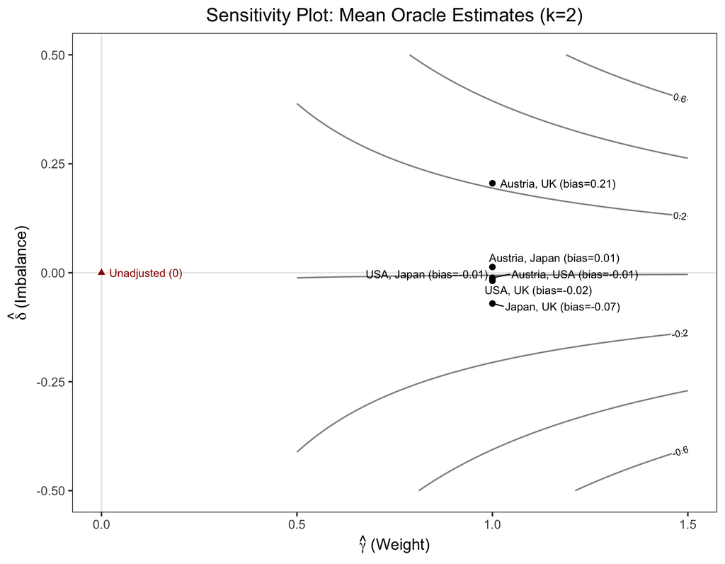

Sensitivity plot with mean oracle estimates for each omitted unit pair (k=2).

```r
# Get oracle estimates for k=2
oracle_data_k2 <- res_drop2_raw |>
    filter(estimator == "Bias-corrected (Infeasible)") |>
    select(id, missing_var, gamma, delta, bias_est)

# Compute mean oracle estimates for each omitted unit pair
oracle_summary_k2 <- oracle_data_k2 |>
    group_by(missing_var) |>
    summarise(
        mean_gamma = mean(gamma),
        mean_delta = mean(delta),
        mean_bias = mean(bias_est),
        .groups = "drop"
    )

# Use plot_sensitivity from scmsens and add contour labels
p_k2 <- plot_sensitivity(
    tau_complete = tau_complete_val,
    var_x_gamma = oracle_summary_k2$mean_gamma,
    var_x_delta = oracle_summary_k2$mean_delta,
    var_x_name = paste0(oracle_summary_k2$missing_var, " (bias=", round(oracle_summary_k2$mean_bias, 2), ")"),
    title = "Sensitivity Plot: Mean Oracle Estimates (k=2)",
    repel = TRUE,
    text_size = 3.5
)

# Add contour labels using metR
gamma_seq_k2 <- seq(round(min(oracle_summary_k2$mean_gamma), 0) - 0.5,
                    round(max(oracle_summary_k2$mean_gamma), 0) + 0.5, length.out = 100)
delta_seq_k2 <- seq(round(min(oracle_summary_k2$mean_delta), 0) - 0.5,
                    round(max(oracle_summary_k2$mean_delta), 0) + 0.5, length.out = 100)
sens_df_k2 <- expand.grid(gamma = gamma_seq_k2, delta = delta_seq_k2) |>
    mutate(tau_adj = tau_complete_val + gamma * delta)

p_k2 + metR::geom_text_contour(data = sens_df_k2, aes(x = gamma, y = delta, z = tau_adj),
                               stroke = 0.2, size = 3, skip = 1)
```

### Decomposition Accuracy

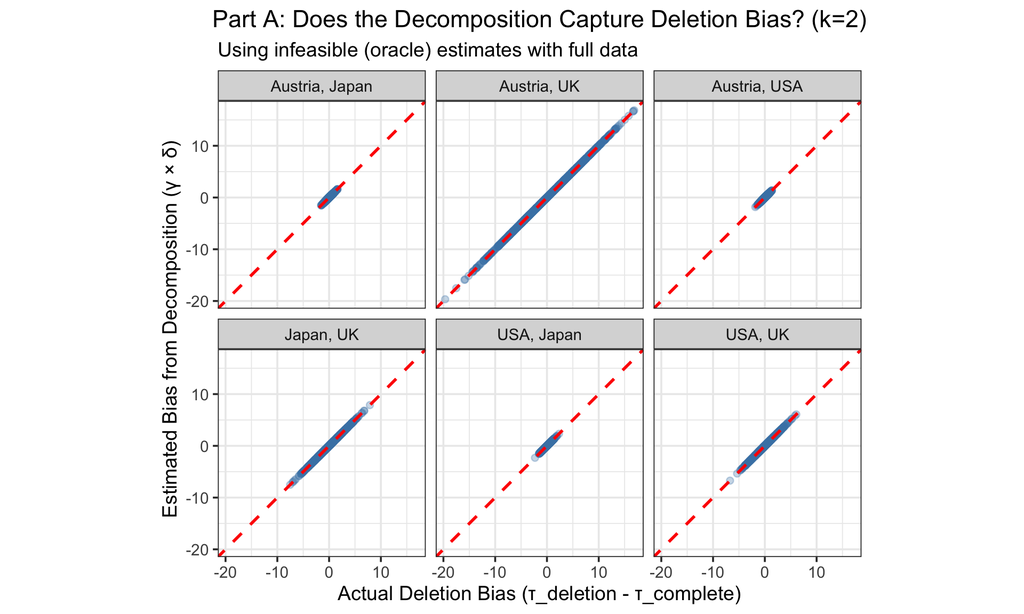

Scatter plot showing actual deletion bias vs estimated bias from the decomposition (k=2).

```r
deletion_data_k2 <- res_drop2_raw |>
    filter(estimator == "Unit-wise Deletion") |>
    select(id, missing_var, tau_deletion = tau, tau_complete)

infeasible_data_k2 <- res_drop2_raw |>
    filter(estimator == "Bias-corrected (Infeasible)") |>
    select(id, missing_var, bias_est_infeasible = bias_est)

plot_data_A_k2 <- deletion_data_k2 |>
    left_join(infeasible_data_k2, by = c("id", "missing_var")) |>
    mutate(actual_deletion_bias = tau_deletion - tau_complete)

ggplot(plot_data_A_k2, aes(x = actual_deletion_bias, y = bias_est_infeasible)) +
    geom_point(alpha = 0.3, color = "steelblue") +
    geom_abline(slope = 1, intercept = 0, color = "red", linetype = "dashed", linewidth = 1) +
    labs(x = "Actual Deletion Bias (τ_deletion - τ_complete)",
         y = "Estimated Bias from Decomposition (γ × δ)",
         title = "Part A: Does the Decomposition Capture Deletion Bias? (k=2)",
         subtitle = "Using infeasible (oracle) estimates with full data") +
    coord_fixed() +
    facet_wrap(~ missing_var, ncol = 3)
```

### Decomposition Accuracy Statistics

```r
decomp_accuracy_k2 <- plot_data_A_k2 |>
    group_by(missing_var) |>
    summarise(
        correlation = cor(actual_deletion_bias, bias_est_infeasible),
        mean_actual_bias = mean(actual_deletion_bias),
        mean_estimated_bias = mean(bias_est_infeasible),
        rmse_decomposition = sqrt(mean((actual_deletion_bias - bias_est_infeasible)^2)),
        .groups = "drop"
    )

decomp_accuracy_k2 |>
    kable(digits = 3, caption = "Decomposition Accuracy (k=2): How well does γ×δ capture actual deletion bias?")
```

Decomposition Accuracy (k=2): How well does γ×δ capture actual deletion bias?

| missing_var | correlation | mean_actual_bias | mean_estimated_bias | rmse_decomposition |
| --- | --- | --- | --- | --- |
| Austria, Japan | 1 | 0.013 | 0.013 | 0 |
| Austria, UK | 1 | 0.205 | 0.205 | 0 |
| Austria, USA | 1 | -0.012 | -0.012 | 0 |
| Japan, UK | 1 | -0.071 | -0.071 | 0 |
| USA, Japan | 1 | -0.014 | -0.014 | 0 |
| USA, UK | 1 | -0.019 | -0.019 | 0 |

## Part B: Feasible Correction Performance (k=2)

**Question:** How well does correction using only **partially observed** data perform compared to the oracle when two units are missing?

### Scenario-Specific Performance

```r
tab_multi_scenario <- compute_scenario_stats(res_drop2_raw, tau_true)

tab_multi_scenario |>
    filter(estimator %in% c("Unit-wise Deletion", "Bias-corrected (Infeasible)", "Bias-corrected (Feasible)")) |>
    select(-mean_bias) |>
    pivot_wider(names_from = estimator, values_from = rmse) |>
    kable(digits = 3, caption = "RMSE by Omitted Unit Pair")
```

RMSE by Omitted Unit Pair

| missing_var | Bias-corrected (Feasible) | Bias-corrected (Infeasible) | Unit-wise Deletion |
| --- | --- | --- | --- |
| Austria, Japan | 1.245 | 1.24 | 1.297 |
| Austria, UK | 1.603 | 1.24 | 6.111 |
| Austria, USA | 1.243 | 1.24 | 1.311 |
| Japan, UK | 1.292 | 1.24 | 2.620 |
| USA, Japan | 1.244 | 1.24 | 1.334 |
| USA, UK | 1.276 | 1.24 | 2.148 |

### Scenario-Specific Figure

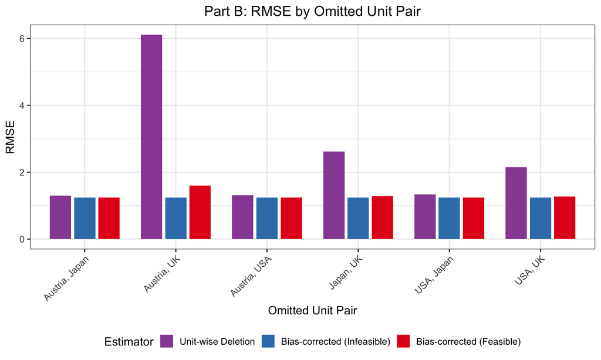

RMSE comparison across omitted unit pairs (k=2)

```r
tab_multi_scenario |>
    filter(estimator %in% c("Unit-wise Deletion", "Bias-corrected (Infeasible)", "Bias-corrected (Feasible)")) |>
    mutate(estimator = factor(estimator, levels = c("Unit-wise Deletion", "Bias-corrected (Infeasible)", "Bias-corrected (Feasible)"))) |>
    ggplot(aes(x = missing_var, y = rmse, fill = estimator)) +
    geom_col(position = position_dodge(width = 0.8), width = 0.7) +
    scale_fill_manual(values = estimator_colors) +
    labs(x = "Omitted Unit Pair", y = "RMSE", fill = "Estimator",
         title = "Part B: RMSE by Omitted Unit Pair") +
    theme(axis.text.x = element_text(angle = 45, hjust = 1),
          legend.position = "bottom")
```

### Gap Recovered

```r
gap_recovered_k2 <- tab_multi_scenario |>
    filter(estimator %in% c("Unit-wise Deletion", "Bias-corrected (Infeasible)", "Bias-corrected (Feasible)")) |>
    select(missing_var, estimator, rmse) |>
    pivot_wider(names_from = estimator, values_from = rmse) |>
    mutate(
        deletion_gap = `Unit-wise Deletion` - `Bias-corrected (Infeasible)`,
        feasible_improvement = `Unit-wise Deletion` - `Bias-corrected (Feasible)`,
        gap_recovered_pct = feasible_improvement / deletion_gap * 100
    )

gap_recovered_k2 |>
    select(missing_var, deletion_gap, feasible_improvement, gap_recovered_pct) |>
    kable(digits = 1, caption = "Gap Recovered by Feasible Correction (k=2)",
          col.names = c("Omitted Pair", "Deletion Gap", "Feasible Improvement", "Gap Recovered (%)"))
```

Gap Recovered by Feasible Correction (k=2)

| Omitted Pair | Deletion Gap | Feasible Improvement | Gap Recovered (%) |
| --- | --- | --- | --- |
| Austria, Japan | 0.1 | 0.1 | 91.1 |
| Austria, UK | 4.9 | 4.5 | 92.6 |
| Austria, USA | 0.1 | 0.1 | 96.7 |
| Japan, UK | 1.4 | 1.3 | 96.3 |
| USA, Japan | 0.1 | 0.1 | 96.1 |
| USA, UK | 0.9 | 0.9 | 96.1 |

### Feasible vs Oracle Comparison

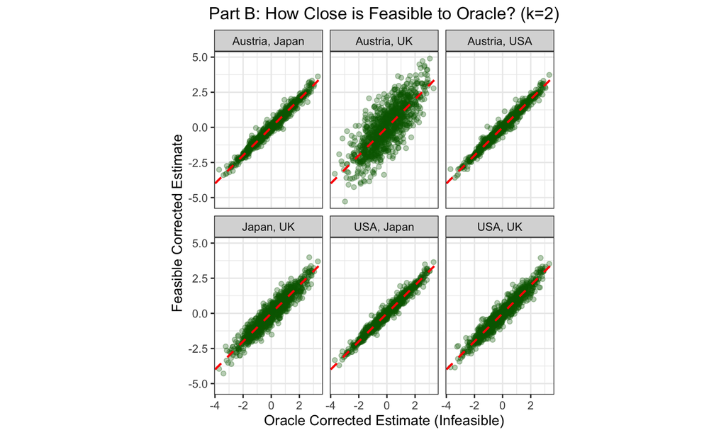

Scatter plot comparing feasible vs oracle corrected estimates (k=2).

```r
res_drop2_raw |>
    filter(estimator %in% c("Bias-corrected (Infeasible)", "Bias-corrected (Feasible)")) |>
    select(id, missing_var, estimator, tau) |>
    pivot_wider(names_from = estimator, values_from = tau) |>
    ggplot(aes(x = `Bias-corrected (Infeasible)`, y = `Bias-corrected (Feasible)`)) +
    geom_point(alpha = 0.3, color = "darkgreen") +
    geom_abline(slope = 1, intercept = 0, color = "red", linetype = "dashed", linewidth = 1) +
    labs(x = "Oracle Corrected Estimate (Infeasible)",
         y = "Feasible Corrected Estimate",
         title = "Part B: How Close is Feasible to Oracle? (k=2)") +
    coord_fixed() +
    facet_wrap(~ missing_var, ncol = 3)
```

### Feasible vs Oracle Correlation

```r
feasible_oracle_corr_k2 <- res_drop2_raw |>
    filter(estimator %in% c("Bias-corrected (Infeasible)", "Bias-corrected (Feasible)")) |>
    select(id, missing_var, estimator, tau) |>
    pivot_wider(names_from = estimator, values_from = tau) |>
    group_by(missing_var) |>
    summarise(
        correlation = cor(`Bias-corrected (Infeasible)`, `Bias-corrected (Feasible)`),
        mean_gap = mean(`Bias-corrected (Feasible)` - `Bias-corrected (Infeasible)`),
        rmse_gap = sqrt(mean((`Bias-corrected (Feasible)` - `Bias-corrected (Infeasible)`)^2)),
        .groups = "drop"
    )

feasible_oracle_corr_k2 |>
    kable(digits = 3, caption = "Feasible vs Oracle (k=2): How similar are the corrections?")
```

Feasible vs Oracle (k=2): How similar are the corrections?

| missing_var | correlation | mean_gap | rmse_gap |
| --- | --- | --- | --- |
| Austria, Japan | 0.986 | 0.014 | 0.208 |
| Austria, UK | 0.780 | 0.055 | 1.004 |
| Austria, USA | 0.986 | 0.011 | 0.209 |
| Japan, UK | 0.945 | -0.005 | 0.422 |
| USA, Japan | 0.985 | 0.007 | 0.214 |
| USA, UK | 0.961 | 0.002 | 0.353 |

# Summary

```r
rmse_complete <- tab_single_overall |> filter(estimator == "Complete Observations") |> pull(rmse)
rmse_deletion <- tab_single_overall |> filter(estimator == "Unit-wise Deletion") |> pull(rmse)
rmse_infeasible <- tab_single_overall |> filter(estimator == "Bias-corrected (Infeasible)") |> pull(rmse)
rmse_feasible <- tab_single_overall |> filter(estimator == "Bias-corrected (Feasible)") |> pull(rmse)

deletion_gap <- rmse_deletion - rmse_infeasible
feasible_improvement <- rmse_deletion - rmse_feasible
gap_recovered <- feasible_improvement / deletion_gap * 100
```

**Key Findings (Single Missing Unit):**

| Metric | Value |
| --- | --- |
| Complete Observations RMSE | 1.24 |
| Unit-wise Deletion RMSE | 1.528 |
| Bias-corrected (Infeasible) RMSE | 1.24 |
| Bias-corrected (Feasible) RMSE | 1.254 |
| Deletion gap (deletion - oracle) | 0.287 |
| Feasible improvement | 0.273 |
| **Gap recovered by feasible** | **95.2%** |

**Interpretation:**

> The feasible correction removes a substantial portion of deletion bias and approaches the oracle benchmark. This suggests that the proposed decomposition recovers most of the systematic component of deletion bias from partially observed outcomes alone.

# Future Extensions

This simulation study uses an augmented-factor IFE design calibrated to the West Germany reunification data. Several extensions could further strengthen the analysis:

**Actual Data Application:**

- Germany leave-one-out decomposition using pseudo-inverse bias decomposition with original pre-treatment periods (no factor augmentation)
- Time-varying decomposition across all post-treatment years (1990-2003)

**Alternative Estimation Methods:**

- Simplex-constrained SCM weights (original Abadie et al. formulation)

**Full Donor Pool Simulation:**

- Current simulation uses 4 control units (Austria, USA, Japan, UK) — the three largest-weight donors plus one additional
- Extend to all 16 OECD control units from the original Abadie et al. study for a more comprehensive evaluation

**Robustness to Missingness Patterns:**

- Early-block vs late-block missingness
- Random missingness patterns
- Varying proportions of missing data (25%, 50%, 75%)

**Additional Visualizations:**

- IFE-based sensitivity plots incorporating factor uncertainty
- Donor-specific time paths showing gap recovery (e.g., Japan)